# Lab 4 - George

## APIs

**Question 1**

This API call finds sites at a minimum of 5000 meters, which only applies to 7 sites. This makes sense, because it’s more difficult to core lakes at so high an elevation. http://api.neotomadb.org/v1/data/sites?altmin=5000

This API call finds all sites in Australia, which returned 18 results. I thought it was interesting that most of the lakes were glacial, which made me realize how little I know about the glacial history of the Southern hemisphere. http://api.neotomadb.org/v1/data/sites?gpid=303

**Question 2**

This API call finds all sites in Wisconsin with *Picea.* http://api.neotomadb.org/v1/data/datasets?gpid=9227&taxonname=*picea*

This API call downloads the pollen dataset for Devils Lake, WI. http://api.neotomadb.org/v1/data/downloads/684

**Question 3**

This API call returns 50 records from the Geochronology table http://api.neotomadb.org/v1/dbtables/Geochronology?limit=50

## Importing Neotoma Data into R and *neotoma*

```r
# Installs and loads necessary packages
install.packages('neotoma', repos='http://cran.us.r-project.org')
install.packages("analogue", repos='http://cran.us.r-project.org')
install.packages("rioja", repos='http://cran.us.r-project.org')
install.packages("rworldmap", repos='http://cran.us.r-project.org')
library(neotoma)
library(analogue)
library(rioja)
library(rworldmap)
```

**Question 4**

```r
#
get_site(sitename='*clear*')
```

```
## The API call was successful, you have returned  48 records.
```

```
##                                     site.name       long      lat elev
##  Clear Lake                                    -93.42973 43.12507  374
##  Clear Lake                                    -86.54460 41.63853  244
##  Clear Pond                                    -78.95336 33.79890   10
##  Clearwater Lake                              -107.93333 50.87361  686
##  Clear Pond                                    -74.01695 43.74858  513
##  Clear Pond                                    -73.59359 43.83965  432
##  Clearwater Pond                               -70.08000 44.72000  172
##  Clear                                         -89.35361 45.61639  474
##  Clear Lake                                    -84.94160 43.89337  357
##  Clear Lake                                    -85.39333 43.67858  324
##  Clear Creek Local Fauna [Trietsch Pit]        -97.00000 33.25000   NA
##  McCleary [48NA1152]                          -106.75000 42.86667 2438
##  Clear Lake Sand and Gravel                    -89.50000 39.75000  159
##  Clear Lake Village [11T1]                     -89.89861 40.43639   NA
##  Clear Lake                                   -117.69621 47.52827  714
##  Clear Lake                                    -85.26828 42.50971  288
##  Clear Lake                                   -112.62796 39.10234 1399
##  Clearwater Bog                               -101.25880 54.02360  266
##  Clear Lake                                   -122.76535 39.01964  404
##  Clear Lake                                    -93.00147 45.26108   NA
##  Clear Lake                                    -92.80000 45.16667   NA
##  Clinton Nuclear                               -88.83259 40.17190  225
##  Clear                                         -95.95457 44.32653  510
##  Kaufman Lake [Clear Lake]                     -88.28934 40.11534  222
##  Clear Lake                                    -78.71667 45.18333   NA
##  Little Clear                                  -79.00996 45.40469   NA
##  Clearwater Lake                               -81.05091 46.37024  283
##  Clearsilver Lake                              -81.25695 46.11884  227
##  Clearwater (Atikameg) Lake                   -101.11000 54.00000   NA
##  Clear Lake                                    -79.01000 45.03000   NA
##  Clear Pong (E.L.)                             -73.83055 43.99722  584
##  Lake Clear                                    -77.24000 45.45000   NA
##  Big Clear Lake                                -76.90000 44.72000   NA
##  Clear Lake                                    -78.20017 44.51266   NA
##  Clear Lake                                   -100.00000 50.66000   NA
##  Big Clear Lake?                               -76.79000 44.73000   NA
##  Clearwater Lake                               -81.55556 28.97778   14
##  Cleary Creek [Upper Cleary Creek] [AKLIV-VP] -147.33333 65.08333   NA
##  Clear Lake                                    -89.22055 45.35416  543
##  Clear Creek Lake                              -95.45271 39.63918  322
##  Clear Creek Reservoir                        -117.15336 45.06233 2108
##  Clear Creek Lake                              -95.45271 39.63918  322
##  Clear Creek Reservoir                        -117.15336 45.06233 2108
##  Clear Lake                                   -121.70443 45.18038 1073
##  Clearwater Lake                               -90.79087 37.14689  152
##  Upper Clear Boggy Creek Site 9 Reservoir      -96.50308 34.52420  214
##  Clear Lake                                   -124.07961 44.02384   30
##  Clearwater Lake                               -81.83272 28.16664   43
## A site object containing 48 sites and 8 parameters.
```

There are 48 sites with the name ‘clear’ in them.

**Question 5**

```r
WI_sites <- get_site(gpid = 9227)
```

```
## The API call was successful, you have returned  459 records.
```

```r
MN_sites <- get_site(gpid = 7467)
```

```
## The API call was successful, you have returned  518 records.
```

Minnesota (518 records) has more sites than Wisconsin (459 records).

**Question 6**

```r
# Finds site with name 'devil*' in Wisconsin and downloads Devil's lake data
devils_lake <- get_site(sitename = 'devil*', gpid = 9227)
```

```
## The API call was successful, you have returned  1 records.
```

```r
devilslake.meta.dataset  <- get_dataset(devils_lake)
# Prints Devil's Lake metadata
print(devilslake.meta.dataset)
```

```
## A dataset_list containing 5 objects:
## Accessed from 2018-10-13 00:01h to 2018-10-13 00:01h.
## Datasets:
##  dataset.id   site.name      long     lat                     type
##         684 Devils Lake -89.73205 43.4178 pollen
##        3802 Devils Lake -89.73205 43.4178 pollen surface sample
##        8060 Devils Lake -89.73205 43.4178 geochronologic
##       14858 Devils Lake -89.73205 43.4178 water chemistry
##       14859 Devils Lake -89.73205 43.4178 ostracode surface sample
```

There are 5 types of datasets at Devil’s Lake, WI.

**Question 7**

```r
# Gets list of available datasets from Jemima Lake in MA
jemima_dataset <- get_dataset(10026)

# Stores data associated with each Jemima Lake dataset
jemima_data <- get_download(jemima_dataset)

# Assigns the first (and only) dataset, which is pollen, to jemima_pollen
jemima_pollen <- jemima_data[[1]]

# Compiles Jemima Lake pollen data using the p25 list
jemima_pollen_p25 <- compile_taxa(jemima_data[[1]], list.name = "P25")

# Checks which pollen has been converted by looking at new taxon table
jemima_pollen_p25$taxon.list[,c("compressed", "taxon.name")]
```

```
##               compressed                           taxon.name
## 1                  Abies                                Abies
## 2                   Acer                          Acer rubrum
## 3                   Acer                       Acer saccharum
## 4                  Alnus                         Alnus incana
## 5                  Alnus          Alnus viridis subsp. crispa
## 6                  Other                        Amaranthaceae
## 7          Prairie Forbs                             Ambrosia
## 8                  Other                             Apiaceae
## 9          Prairie Forbs                            Artemisia
## 10         Prairie Forbs Asteraceae subf. Asteroideae undiff.
## 11         Prairie Forbs       Asteraceae subf. Cichorioideae
## 12                Betula                       Betula undiff.
## 13                 Other                   Betulaceae undiff.
## 14                 Carya                                Carya
```

[output cut: 66 more lines]

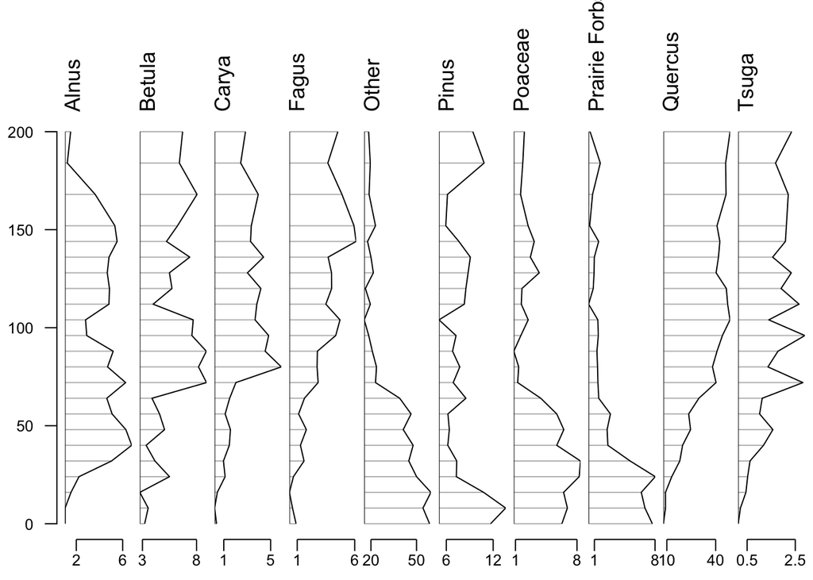

```r
#rioja plot process
# Divides raw pollen counts by total pollen count and multiplies by 100 to get percentages
jemima_pollen_p25[is.na(jemima_pollen_p25)] <- 0
percentages <- 100*(jemima_pollen_p25$counts/rowSums(jemima_pollen_p25$counts))

# Selects only taxa with at least two peaks of at least 2%
inclusion.criterion <- apply(percentages,2,function(x) (sum(x>2))>1)
percentages_clean <- percentages[,inclusion.criterion]

#Defines y-axis using depth data from jemima pollen
depths <- as.numeric(as.character(unlist(jemima_pollen_p25$sample.meta$depth)))

# Creates stratigraphic diagram of taxa with two peaks of at least 3%
rioja::strat.plot(percentages_clean, yvar = depths, ylabel = "Depth (cm)")
```

**Question 8**

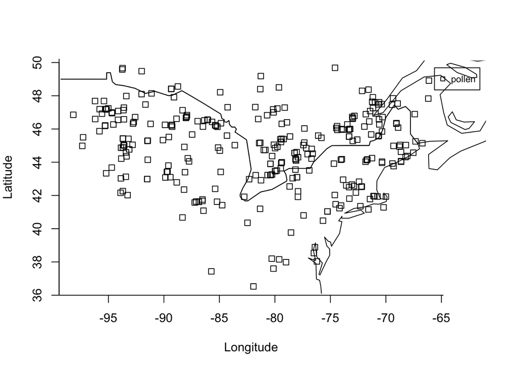

```r
#assigns getMap function to map
map <- getMap()

# Search for datasets with Picea in them
pic_dec <- get_dataset(taxonname = "Picea*",
                       datasettype = "pollen",
                       loc = c(-98.6, 36.5, -66.1, 49.75),
                       ageyoung = 4500, ageold = 6000)
# Download the datasets (this will take a few minutes)
pic_dec_dl <- get_download(pic_dec)

# Plot Picea data on map
plot(pic_dec_dl)
plot(map, add=TRUE)
```

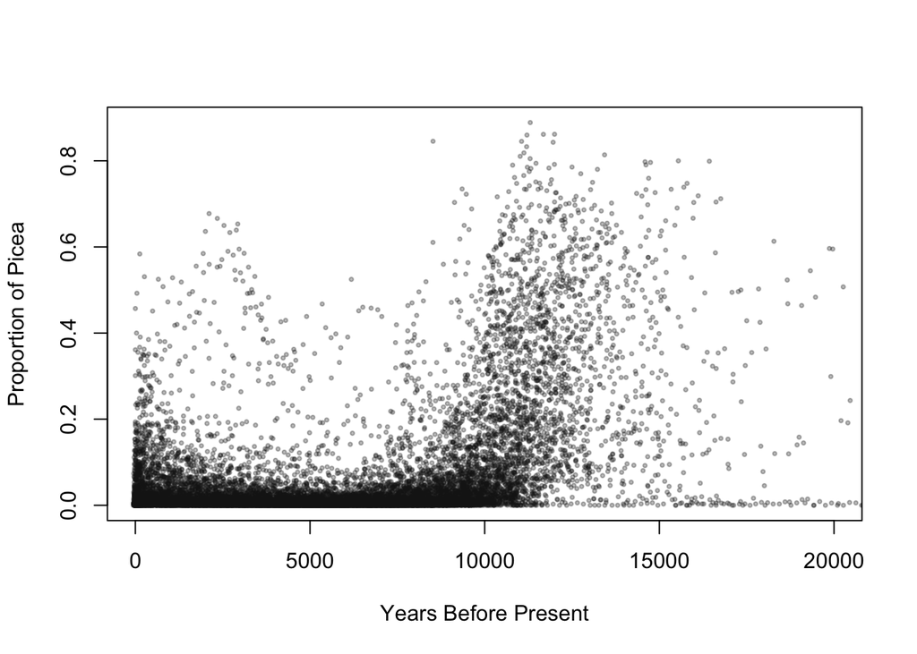

```r
# combines records
pic_compiled <- compile_downloads(pic_dec_dl)

# Extract all taxon tables from the original download object
all_taxa <- do.call(rbind.data.frame, lapply(pic_dec_dl, function(x)x$taxon.list[,1:6]))

# Remove duplicate names
all_taxa <- all_taxa[!duplicated(all_taxa),]

# Limit the taxa to everything that is a tree or shrub, or upland herbs
good_cols <- c(1:10, which(colnames(pic_compiled) %in%
      gsub("[ ]|[[:punct:]]", ".",
      all_taxa[all_taxa$ecological.group %in%
      c("TRSH", "UPHE"),1])))

# Take just those trees, shrubs & herbs and transform counts to proportions:
pic_compiled <- pic_compiled[ ,good_cols]

pic_pct <- pic_compiled[,11:ncol(pic_compiled)] / rowSums(pic_compiled[,11:ncol(pic_compiled)], na.rm = TRUE)

pic_only <- rowSums(pic_pct[,grep("Picea", colnames(pic_pct))], na.rm = TRUE)

# Pull ages from the compiled_downloads object by taking the rowMeans of the age columns
age_cols <- grep("^age", colnames(pic_compiled))

picea_all <- data.frame(ages = rowMeans(pic_compiled[,age_cols], na.rm = TRUE),
                          prop = pic_only)
# plot picea against age
plot(picea_all, col = rgb(0.1, 0.1, 0.1, 0.3), pch = 19, cex = 0.4,
     xlim = c(0, 20000),
     ylab = "Proportion of Picea",          xlab = "Years Before Present")
```

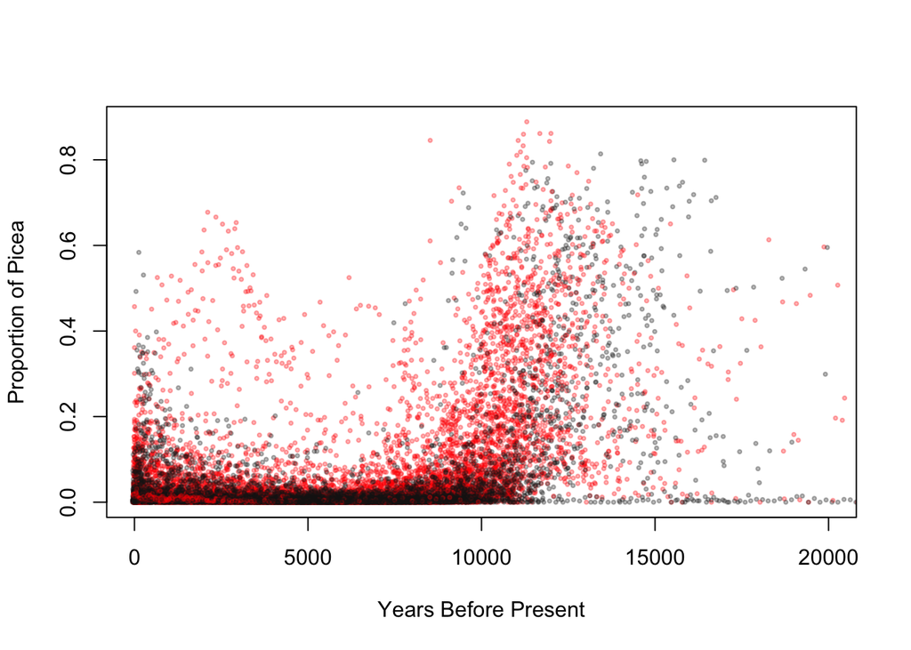

```r
# separates sites with radiocarbon-year chronologies from other date types
plot(picea_all,
     col = c(rgb(0.1, 0.1, 0.1, 0.3),
             rgb(1, 0, 0, 0.3))[(pic_compiled$date.type == "Radiocarbon years BP") + 1],
     pch = 19, cex = 0.4,
     xlim = c(0, 20000),
     ylab = "Proportion of Picea", xlab = "Years Before Present")
```

**Question 9**

```r
# returns set of sites within this bounding box for this one time interval (0 to 500 yr BP)
one_slice <- get_dataset(taxonname='Picea*', loc=c(-110, 40, -80, 50), ageyoung = 0, ageold = 500)
```

```
## The API call was successful, you have returned 304 records.
```

```r
# creates vector of values from 0-21,000, increasing by 1000
increment <- seq(from = 0, to = 21000, by = 1000)

# Replace parameters in original call with the first element of increment variable
one_slice <- get_dataset(taxonname = 'Picea*',
                         loc = c(-110, 40, -80, 50),
                         ageyoung = increment[1],
                         ageold = increment[2])
```

```
## The API call was successful, you have returned 324 records.
```

```r
# increase the values of the indices so that we keep getting new time slices using a for loop. Each time this loop iterates, the time interval defined by ageyounger and ageolder will increment by one
for(i in 1:21){
  one_slice <- get_dataset(taxonname = 'Picea*',
                           datasettype = 'pollen',
                           loc = c(-110, 40, -80, 50),
                           ageyoung = increment[i],
                           ageold = increment[i + 1])
  }
```

```
## The API call was successful, you have returned 324 records.
```

```
## The API call was successful, you have returned 205 records.
```

```
## The API call was successful, you have returned 189 records.
```

```
## The API call was successful, you have returned 166 records.
```

```
## The API call was successful, you have returned 158 records.
##
## The API call was successful, you have returned 158 records.
```

```
## The API call was successful, you have returned 161 records.
```

```
## The API call was successful, you have returned 163 records.
##
## The API call was successful, you have returned 163 records.
```

```
## The API call was successful, you have returned 169 records.
##
## The API call was successful, you have returned 169 records.
```

```
## The API call was successful, you have returned 159 records.
```

```
## The API call was successful, you have returned 138 records.
```

```
## The API call was successful, you have returned 102 records.
```

```
## The API call was successful, you have returned 69 records.
```

```
## The API call was successful, you have returned 56 records.
```

```
## The API call was successful, you have returned 38 records.
```

```
## The API call was successful, you have returned 24 records.
```

```
## The API call was successful, you have returned 21 records.
```

```
## The API call was successful, you have returned 17 records.
```

```
## The API call was successful, you have returned 9 records.
```

```r
# create a new variable, filled with 20 NA values, ready to store data from each iteration of the loop, defines increment
site_nos <- rep(NA, 21)
increment <- seq(from = 0, to = 21000, by = 1000)

# Records # of records for each 1000 year period from 21,000-0.
for (i in 1:20) {one_slice <- get_dataset(taxonname = 'Picea*',
                                          datasettype = 'pollen',
                                          loc = c(-110, 40, -80, 50),
                                          ageyoung = increment[i],
                                          ageold = increment[i + 1])
site_nos[i] <- length(one_slice)
  }
```

```
## The API call was successful, you have returned 324 records.
```

```
## The API call was successful, you have returned 205 records.
```

```
## The API call was successful, you have returned 189 records.
```

```
## The API call was successful, you have returned 166 records.
```

```
## The API call was successful, you have returned 158 records.
##
## The API call was successful, you have returned 158 records.
```

```
## The API call was successful, you have returned 161 records.
```

```
## The API call was successful, you have returned 163 records.
##
## The API call was successful, you have returned 163 records.
```

```
## The API call was successful, you have returned 169 records.
##
## The API call was successful, you have returned 169 records.
```

```
## The API call was successful, you have returned 159 records.
```

```
## The API call was successful, you have returned 138 records.
```

```
## The API call was successful, you have returned 102 records.
```

```
## The API call was successful, you have returned 69 records.
```

```
## The API call was successful, you have returned 56 records.
```

```
## The API call was successful, you have returned 38 records.
```

```
## The API call was successful, you have returned 24 records.
```

```
## The API call was successful, you have returned 21 records.
```

```
## The API call was successful, you have returned 17 records.
```

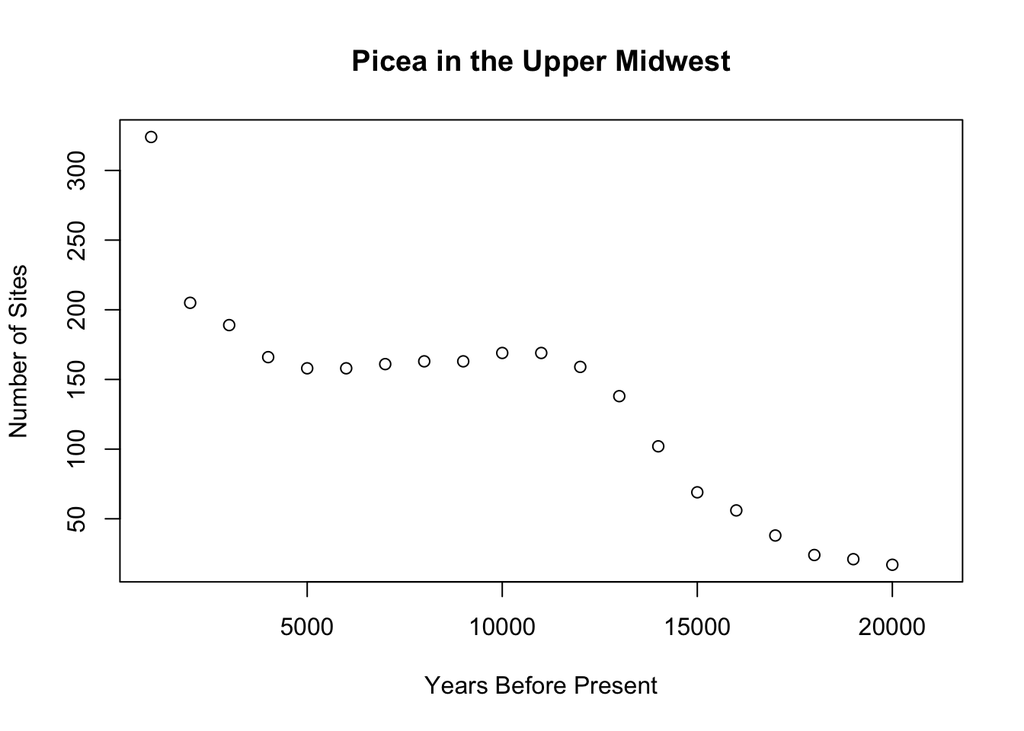

```r
# plot the values and take a look at them
plot(increment[-1], site_nos, main = "Picea in the Upper Midwest", xlab = "Years Before Present", ylab = "Number of Sites")
```

```r
# extracts latitude info
site_lat <- rep(NA, 20)
for (i in 1:20) {
  all_site <- get_site(get_dataset(taxonname = 'Picea*',
                                   datasettype = 'pollen',
                                   loc = c(-110, 40, -80, 50),
                                   ageyoung = increment[i],
                                   ageold = increment[i + 1]))
site_lat[i] <- mean(all_site$lat)
}
```

Picea steadily increases from 20,000 years ago to about 12,000 years ago in the Upper Midwest. After a plateau of about seven thousand years, it continues to increase until present.